# QK Box 11.5

Hey et al. (2020) studied the effect of artificial light at night (ALAN) on the growth of a wildflower species (*Asclepias syriaca*) in an outdoor field experiment. The plant, a species of milkweed, is an important host plant for caterpillars of the monarch butterfly.

They used a split-plot design for their experiment. The between-plots factor was ALAN, with five plots receiving artificial light and five control plots with the same set-up but only receiving ambient light. The sub-plots were 11 L small pots and there were two within-plot factors arranged in a crossed design; planting density (one or three plants per pot) and soil moisture (weekly addition of water vs no watering). There were four pots in each plot, so each combination of density and moisture had a single pot; the design is unreplicated at the sub-plot level. The response variable was total biomass (root and shoot) per pant in each pot, averaged across the plants within the higher density pots.

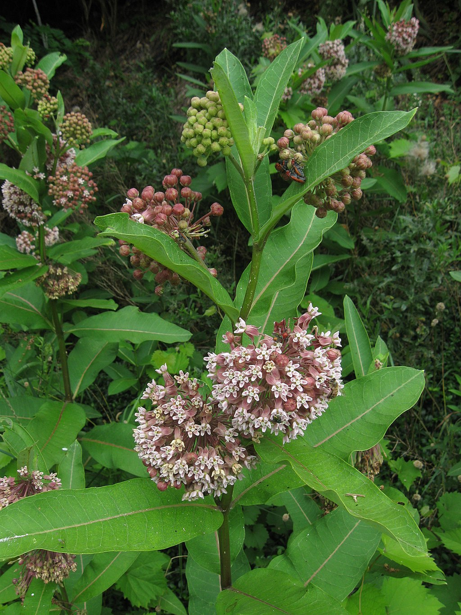

*Asclepias syriaca*. Cbaile19, CC0, via Wikimedia Commons

The paper is [here](https://doi.org/10.1007/s00442-020-04679-9)

Hey, M. H., DiBiase, E., Roach, D. A., Carr, D. E. & Haynes, K. J. (2020). Interactions between artificial light at night, soil moisture, and plant density affect the growth of a perennial wildflower. *Oecologia*, 193, 503-10.

### Preliminaries

First, load the required packages (afex, car, lattice, lme4, lmerTest, nlme, VCA, ez, emmeans, Rmisc, MuMIn)

Import heymean data file (heymean.csv)

```r
heymean <- read.csv("../data/heymean.csv")
heymean
```

| plot | pot | id | light | water | density | finaldam | dwtotal |
| --- | --- | --- | --- | --- | --- | --- | --- |
| 1 | 3 | 1A | Lit | Water | Low | 3.00 | 0.560 |
| 1 | 4 | 1B | Lit | NW | High | 1.67 | 0.837 |
| 1 | 2 | 1E | Lit | NW | Low | NA | 0.050 |
| 1 | 1 | 1F | Lit | Water | High | 3.00 | 0.900 |
| 2 | 1 | 2A | Lit | Water | Low | 2.00 | 0.700 |
| 2 | 2 | 2B | Lit | NW | High | 2.00 | 0.503 |
| 2 | 3 | 2E | Lit | NW | Low | 5.00 | 0.530 |
| 2 | 4 | 2F | Lit | Water | High | 3.67 | 0.483 |
| 3 | 2 | 3A | Control | Water | Low | 2.00 | 0.820 |
| 3 | 4 | 3B | Control | NW | High | 2.33 | 0.793 |

[output cut: 30 more lines]

Set contrasts from afex

Make plot a factor

```r
set_sum_contrasts()
```

```r
heymean$plot <- factor(heymean$plot)
```

Check residuals by leaving out error term

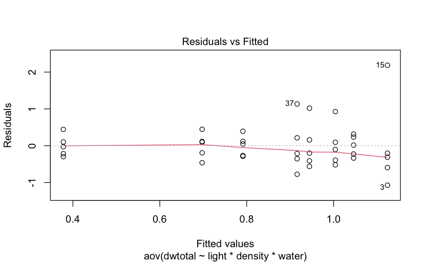

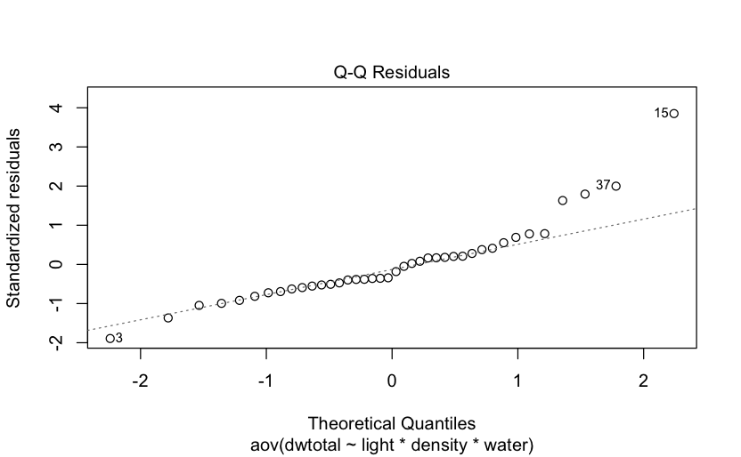

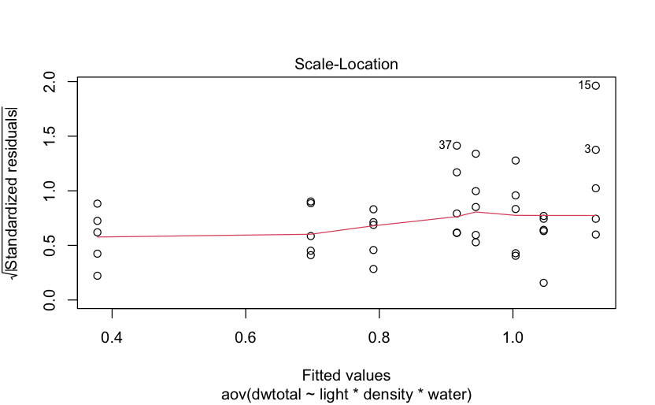

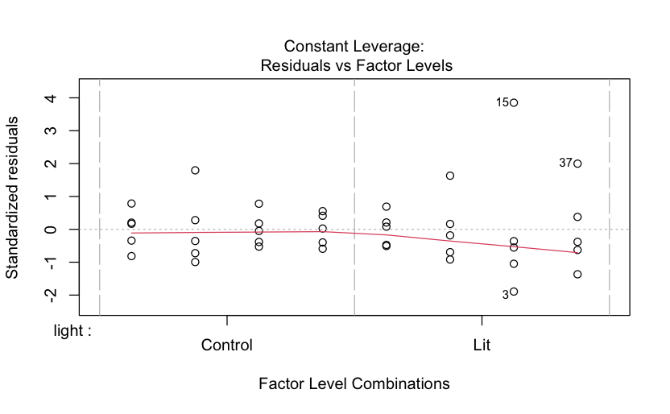

```r
hey1.aov <- aov(dwtotal~light*density*water, heymean)
plot(hey1.aov)
```

See if transformation improves the residuals

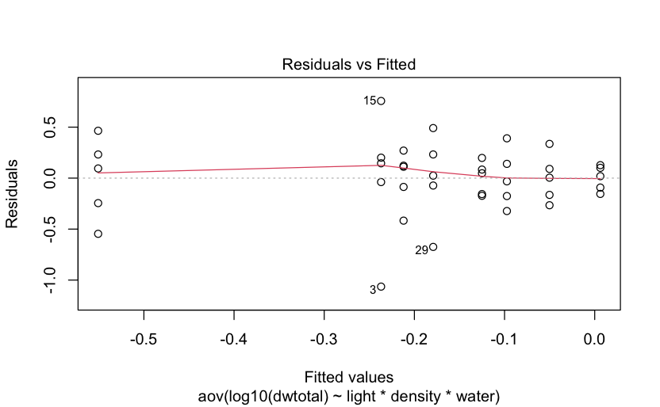

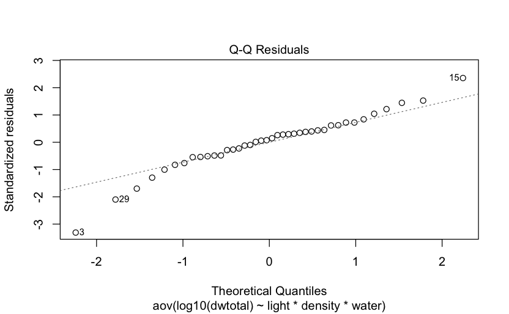

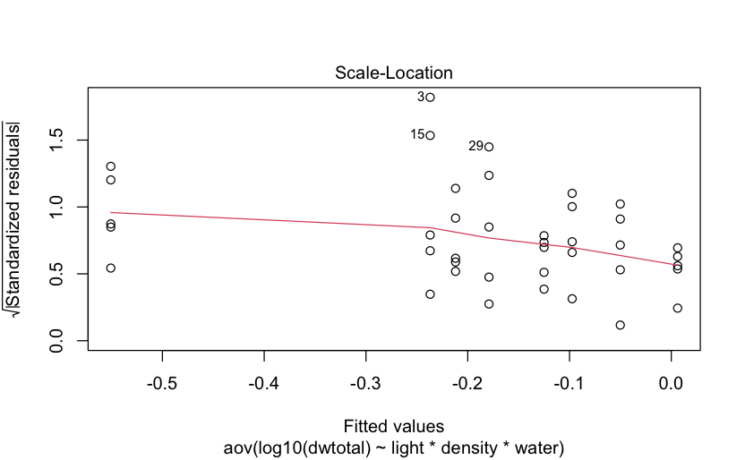

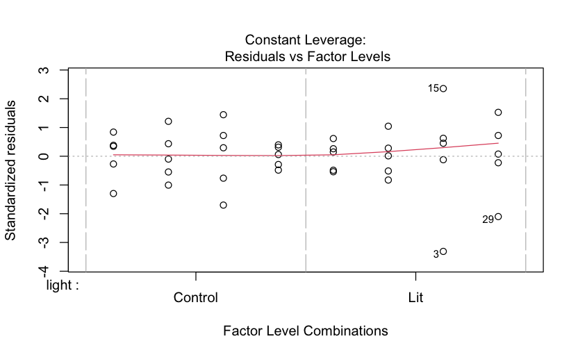

```r
hey2.aov <- aov(log10(dwtotal)~light*density*water, heymean)
plot(hey2.aov)
```

Some improvement in plot; outliers still present but transform response

**Note** Biomass is always positive, so we don’t really need to add anything before transforming. Hey et al. used a log(x+1) transformation, so we’ll do the same here for consistency. As an exercise, you could modify the next line of code to remove the +1 and rerun the model-fitting to see how much difference there is.

```r
heymean$ldwtotal <- log10(heymean$dwtotal+1)
```

## Fit factorial split-plot with separate within-plot error terms

```r
hey3.aov <- aov(ldwtotal~light*density*water+Error(plot/(density*water)), heymean)
summary(hey3.aov)
```

```
Error: plot
          Df Sum Sq Mean Sq F value Pr(>F)
light      1 0.0121  0.0121    0.33   0.58
Residuals  8 0.2925  0.0366

Error: plot:density
              Df Sum Sq Mean Sq F value Pr(>F)
density        1 0.0021 0.00212    0.21   0.66
light:density  1 0.0017 0.00172    0.17   0.69
Residuals      8 0.0820 0.01025

Error: plot:water
            Df Sum Sq Mean Sq F value Pr(>F)
water        1 0.0386  0.0386    4.38   0.07 .
light:water  1 0.0258  0.0258    2.93   0.13
Residuals    8 0.0704  0.0088
---
Signif. codes:  0 ‘***’ 0.001 ‘**’ 0.01 ‘*’ 0.05 ‘.’ 0.1 ‘ ’ 1

Error: plot:density:water
                    Df Sum Sq Mean Sq F value Pr(>F)
density:water        1 0.0029 0.00289    0.29   0.60
light:density:water  1 0.0211 0.02112    2.12   0.18
Residuals            8 0.0796 0.00995
```

## Fit equivalent mixed effects model

```r
hey1.lmer <- lmer(ldwtotal~light+density+water+light*density+light*water+density*water+light*density*water+(1|plot)+(1|plot:density)+(1|plot:water), REML=TRUE, heymean)
```

```
boundary (singular) fit: see help('isSingular')
```

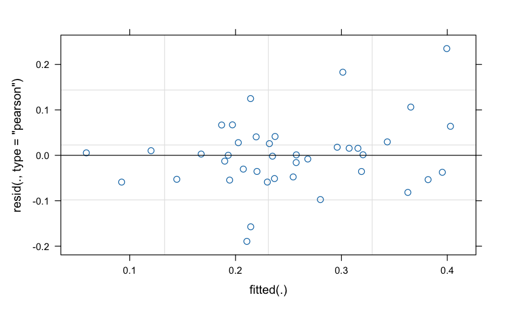

```r
plot(hey1.lmer)
```

residuals OK

```r
summary(hey1.lmer, ddf="Kenward-Roger")
```

```
Linear mixed model fit by REML. t-tests use Kenward-Roger's method ['lmerModLmerTest']
Formula: ldwtotal ~ light + density + water + light * density + light *      water + density * water + light * density * water + (1 |      plot) + (1 | plot:density) + (1 | plot:water)
   Data: heymean

REML criterion at convergence: -17.5

Scaled residuals:
    Min      1Q  Median      3Q     Max
-1.9570 -0.5011  0.0056  0.2921  2.4266

Random effects:
 Groups       Name        Variance Std.Dev.
 plot:water   (Intercept) 0.000000 0.0000
 plot:density (Intercept) 0.000436 0.0209
 plot         (Intercept) 0.006579 0.0811
 Residual                 0.009376 0.0968
Number of obs: 40, groups:  plot:water, 20; plot:density, 20; plot, 10

Fixed effects:
                       Estimate Std. Error       df t value Pr(>|t|)
(Intercept)             0.25082    0.03023  8.00000    8.30  3.4e-05 ***
light1                 -0.01736    0.03023  8.00000   -0.57    0.582
density1                0.00728    0.01601  8.00000    0.45    0.661
water1                 -0.03105    0.01531  8.00000   -2.03    0.077 .
light1:density1         0.00655    0.01601  8.00000    0.41    0.693
light1:water1          -0.02539    0.01531  8.00000   -1.66    0.136
density1:water1         0.00850    0.01531  8.00000    0.56    0.594
light1:density1:water1  0.02298    0.01531  8.00000    1.50    0.172
---
Signif. codes:  0 ‘***’ 0.001 ‘**’ 0.01 ‘*’ 0.05 ‘.’ 0.1 ‘ ’ 1

Correlation of Fixed Effects:
            (Intr) light1 dnsty1 water1 lght1:d1 lght1:w1 dns1:1
light1      0.000
density1    0.000  0.000
water1      0.000  0.000  0.000
lght1:dnst1 0.000  0.000  0.000  0.000
light1:wtr1 0.000  0.000  0.000  0.000  0.000
dnsty1:wtr1 0.000  0.000  0.000  0.000  0.000    0.000
lght1:dn1:1 0.000  0.000  0.000  0.000  0.000    0.000    0.000
optimizer (nloptwrap) convergence code: 0 (OK)
boundary (singular) fit: see help('isSingular')
```

```r
anova(hey1.lmer, ddf="Kenward-Roger")
```

```
Type III Analysis of Variance Table with Kenward-Roger's method
                    Sum Sq Mean Sq NumDF DenDF F value Pr(>F)
light               0.0031  0.0031     1     8    0.33  0.582
density             0.0019  0.0019     1     8    0.21  0.661
water               0.0386  0.0386     1     8    4.11  0.077 .
light:density       0.0016  0.0016     1     8    0.17  0.693
light:water         0.0258  0.0258     1     8    2.75  0.136
density:water       0.0029  0.0029     1     8    0.31  0.594
light:density:water 0.0211  0.0211     1     8    2.25  0.172
---
Signif. codes:  0 ‘***’ 0.001 ‘**’ 0.01 ‘*’ 0.05 ‘.’ 0.1 ‘ ’ 1
```

### Get variance components

```r
hey1.ci <- confint.merMod(hey1.lmer, oldNames=FALSE)
```

[output not shown]

```r
hey1.vc <- (hey1.ci)^2
print(hey1.vc)
```

```
                               2.5 %   97.5 %
sd_(Intercept)|plot:water   0.00e+00 6.34e-03
sd_(Intercept)|plot:density 0.00e+00 6.91e-03
sd_(Intercept)|plot         3.08e-04 1.84e-02
sigma                       4.37e-03 1.33e-02
(Intercept)                 3.71e-02 9.56e-02
light1                      5.73e-03 1.68e-03
density1                    5.62e-04 1.46e-03
water1                      3.49e-03 9.04e-06
light1:density1             5.97e-04 1.41e-03
light1:water1               2.86e-03 7.03e-06
density1:water1             3.82e-04 1.34e-03
light1:density1:water1      2.57e-05 2.60e-03
```

### Compare this model to model with no plot by density and moisture interactions

```r
hey1a.lmer <- lmer(ldwtotal~light+density+water+light*density+light*water+density*water+light*density*water+(1|plot)+(1|plot:density)+(1|plot:water), REML=FALSE, heymean)
```

```
boundary (singular) fit: see help('isSingular')
```

```r
hey2.lmer <- lmer(ldwtotal~light*density*water+(1|plot), REML=FALSE, heymean)
anova(hey1a.lmer, hey2.lmer)
```

```
Data: heymean
Models:
hey2.lmer: ldwtotal ~ light * density * water + (1 | plot)
hey1a.lmer: ldwtotal ~ light + density + water + light * density + light * water + density * water + light * density * water + (1 | plot) + (1 | plot:density) + (1 | plot:water)
           npar   AIC   BIC logLik deviance Chisq Df Pr(>Chisq)
hey2.lmer    10 -47.7 -30.8   33.8    -67.7
hey1a.lmer   12 -43.7 -23.4   33.8    -67.7  0.03  2       0.99
```

```r
AICc(hey1a.lmer, hey2.lmer)
```

|  | df | AICc |
| --- | --- | --- |
| hey1a.lmer | 12 | -32.1 |
| hey2.lmer | 10 | -40.1 |

Simpler model fits equally well

```r
hey2a.lmer <- lmer(ldwtotal~light*density*water+(1|plot), REML=TRUE, heymean)
summary(hey2a.lmer, ddf="Kenward-Roger")
```

```
Linear mixed model fit by REML. t-tests use Kenward-Roger's method ['lmerModLmerTest']
Formula: ldwtotal ~ light * density * water + (1 | plot)
   Data: heymean

REML criterion at convergence: -17.5

Scaled residuals:
    Min      1Q  Median      3Q     Max
-2.0042 -0.4504 -0.0212  0.2962  2.4499

Random effects:
 Groups   Name        Variance Std.Dev.
 plot     (Intercept) 0.00672  0.0820
 Residual             0.00967  0.0983
Number of obs: 40, groups:  plot, 10

Fixed effects:
                       Estimate Std. Error       df t value Pr(>|t|)
(Intercept)             0.25082    0.03023  8.00000    8.30  3.4e-05 ***
light1                 -0.01736    0.03023  8.00000   -0.57    0.582
density1                0.00728    0.01555 24.00000    0.47    0.644
water1                 -0.03105    0.01555 24.00000   -2.00    0.057 .
light1:density1         0.00655    0.01555 24.00000    0.42    0.677
light1:water1          -0.02539    0.01555 24.00000   -1.63    0.115
density1:water1         0.00850    0.01555 24.00000    0.55    0.590
light1:density1:water1  0.02298    0.01555 24.00000    1.48    0.152
---
Signif. codes:  0 ‘***’ 0.001 ‘**’ 0.01 ‘*’ 0.05 ‘.’ 0.1 ‘ ’ 1

Correlation of Fixed Effects:
            (Intr) light1 dnsty1 water1 lght1:d1 lght1:w1 dns1:1
light1      0.000
density1    0.000  0.000
water1      0.000  0.000  0.000
lght1:dnst1 0.000  0.000  0.000  0.000
light1:wtr1 0.000  0.000  0.000  0.000  0.000
dnsty1:wtr1 0.000  0.000  0.000  0.000  0.000    0.000
lght1:dn1:1 0.000  0.000  0.000  0.000  0.000    0.000    0.000
```

```r
anova(hey2a.lmer, ddf="Kenward-Roger")
```

```
Type III Analysis of Variance Table with Kenward-Roger's method
                    Sum Sq Mean Sq NumDF DenDF F value Pr(>F)
light               0.0032  0.0032     1     8    0.33  0.582
density             0.0021  0.0021     1    24    0.22  0.644
water               0.0386  0.0386     1    24    3.99  0.057 .
light:density       0.0017  0.0017     1    24    0.18  0.677
light:water         0.0258  0.0258     1    24    2.67  0.115
density:water       0.0029  0.0029     1    24    0.30  0.590
light:density:water 0.0211  0.0211     1    24    2.18  0.152
---
Signif. codes:  0 ‘***’ 0.001 ‘**’ 0.01 ‘*’ 0.05 ‘.’ 0.1 ‘ ’ 1
```

### Compare to factorial OLS split-plot pooling within-plot error terms

Same as above for fixed effects

```r
hey4.aov <- aov(ldwtotal~light*density*water+Error(plot), heymean)
summary(hey4.aov)
```

```
Error: plot
          Df Sum Sq Mean Sq F value Pr(>F)
light      1 0.0121  0.0121    0.33   0.58
Residuals  8 0.2925  0.0366

Error: Within
                    Df Sum Sq Mean Sq F value Pr(>F)
density              1 0.0021  0.0021    0.22  0.644
water                1 0.0386  0.0386    3.99  0.057 .
light:density        1 0.0017  0.0017    0.18  0.677
light:water          1 0.0258  0.0258    2.67  0.115
density:water        1 0.0029  0.0029    0.30  0.590
light:density:water  1 0.0211  0.0211    2.18  0.152
Residuals           24 0.2320  0.0097
---
Signif. codes:  0 ‘***’ 0.001 ‘**’ 0.01 ‘*’ 0.05 ‘.’ 0.1 ‘ ’ 1
```